# Презентация по лабораторной работе №8

Поиск файлов. Перенаправление ввода-вывода. Просмотр запущенных процессов

Джаллох Ишмаил

Российский университет дружбы народов, Москва, Россия

04 апреля 2025

# Информация

# Докладчик

- Джаллох Ишмаил
- Студент НКА 05-24
- Факультет физико-математических и естественных наук
- Российский университет дружбы народов
- 1032239614@rudn.ru
- https://Isho-Jah.github.io/ru/

# Цель работы

Ознакомление с инструментами поиска файлов и фильтрации текстовых данных. Приобретение практических навыков: по управлению процессами (и заданиями), по проверке использования диска и обслуживанию файловых систем.

# Перенаправление ввода-вывода

Вошел в систему под моем имением, открыл терминал и записал в файле file.txt названия файлов, содержащихся в каталоге /etc с помощью ls -lR /etc > file.txt :

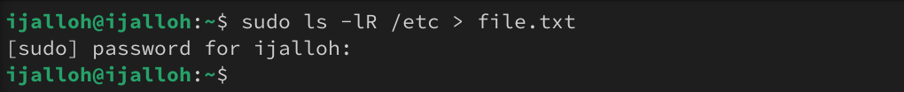

Запись в файл

## Перенаправление ввода-вывода

С помощью head я проверяю ,что в файл записался названия файлов, содержащихся в каталоге /etc:

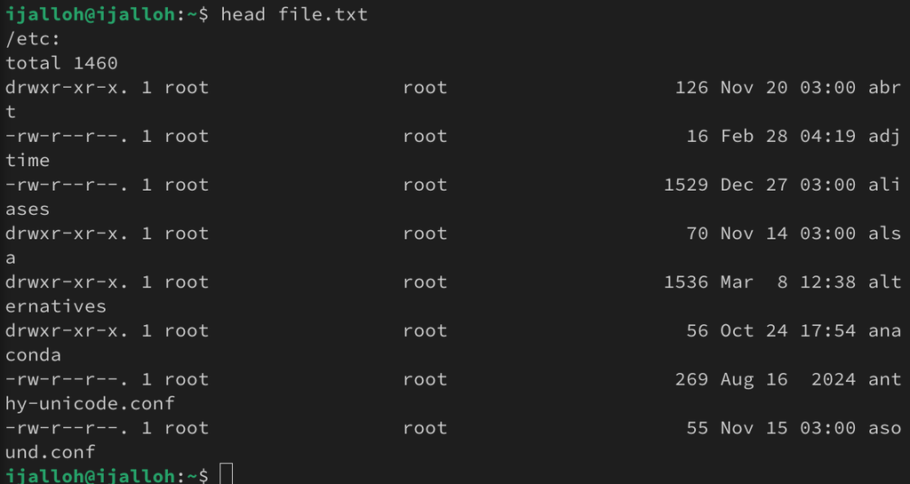

Первые 8 файлов в file.txt

## Перенаправление ввода-вывода

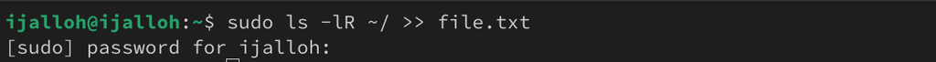

Добавление файлов из домашнего каталога

# Поиск файлов

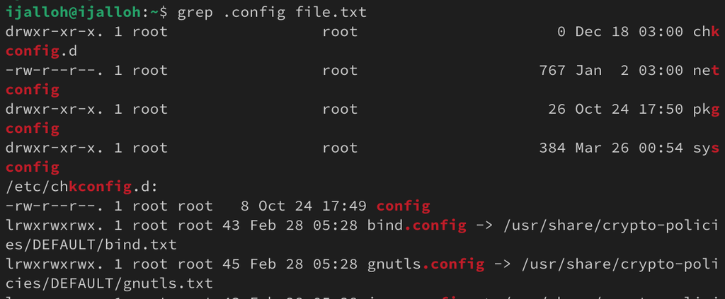

## Поиск файлов

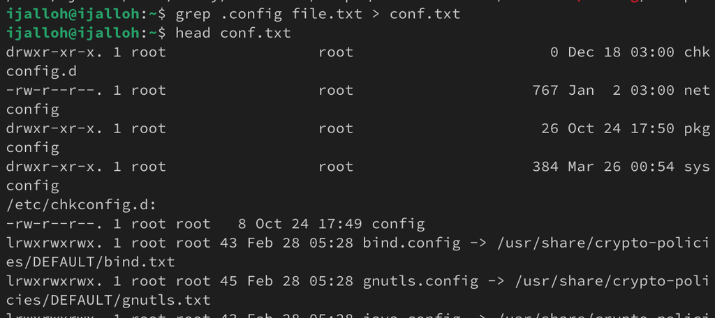

## Поиск файлов

Чтобы определить, какие файлы в домашнем каталоге имеют имена, начинавшиеся с символа “c”, использую find ~ -name “c*” print ; ~ обозначается домашний каталог, -name (имя файлов) ”с* ” строка символов, определяющая имя файла и print выводит результаты на экране:

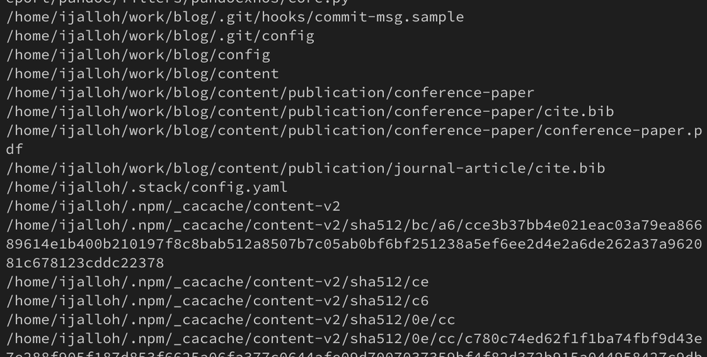

файлы в домашнем каталоге начинающихся с “с”

## Поиск файлов

Также можно это действие выполнить используя ls -lR | grep “c*”

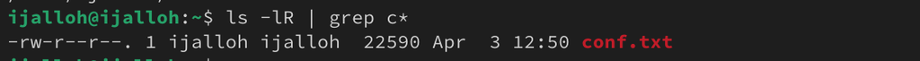

поиск файла используя grep

## Просмотр запущенных процессов

В фоновом режиме запускаю процесс, который будет записывать в файл ~/logfile файлы, имена которых начинаются с log:

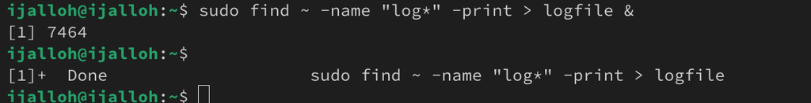

Создание фонового режима

## Просмотр запущенных процессов

Запускаю из консоли в фоновом режиме редактор gedit указывая &:

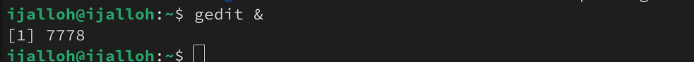

запуск gedit в фоновом режиме

## Просмотр запущенных процессов

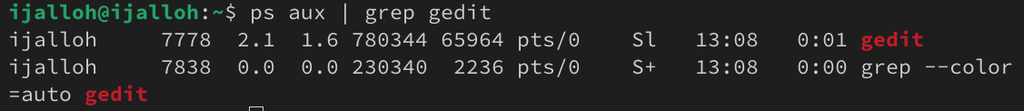

идентификатор процесса gedit

## Просмотр запущенных процессов

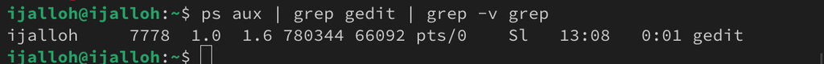

Другой способ нахождение идентификатора процесса

## Просмотр запущенных процессов

С помощью man прочитал справку команды kill и использую её для завершения процесса gedit:

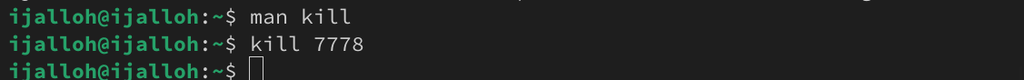

завершения процесса gedit

## Просмотр запущенных процессов

Используя df -vi я вывожу информацию об инодах и вижу сколько свободного места у моей системы:

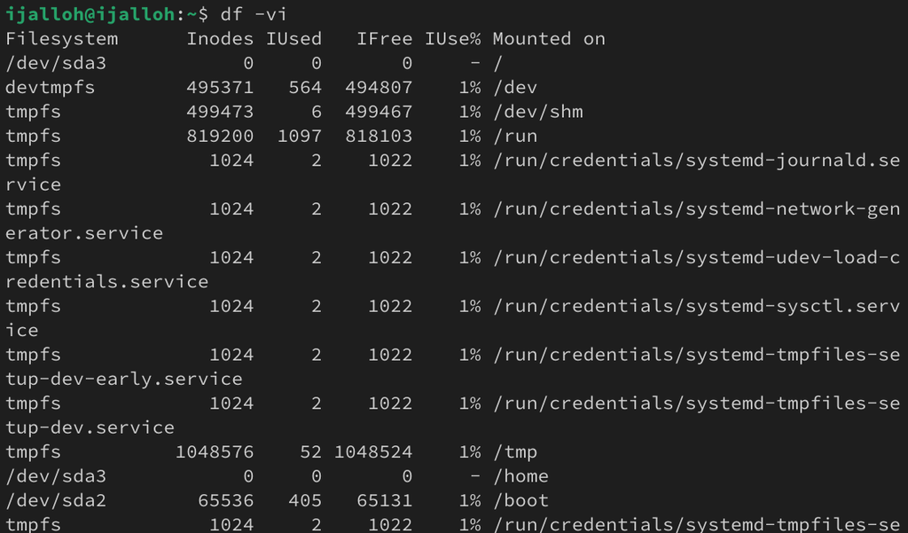

df -vi

## Просмотр запущенных процессов

Используя du -a вижу сколько места занимают файлы в директории Загрузки:

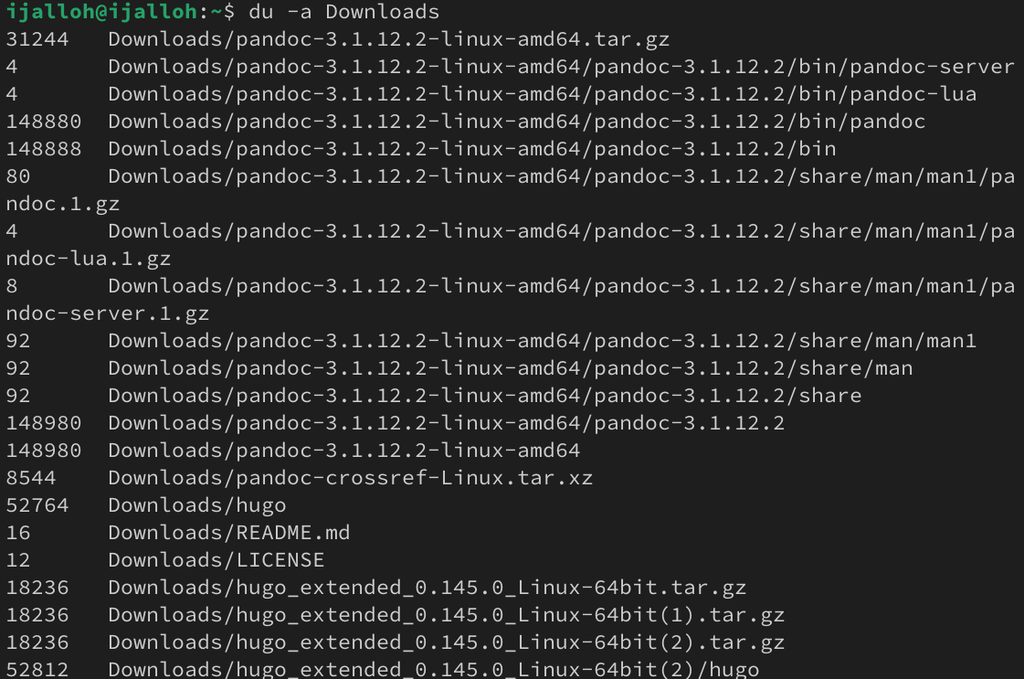

du -a

## Поиск файлов

Воспользовавшись справкой команды find и аргумент d, вывожу всех директорий, имеющихся в домашнем каталоге:

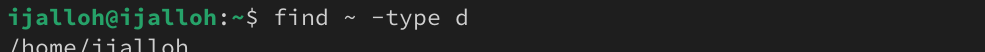

Поиск директорий

## Поиск файлов

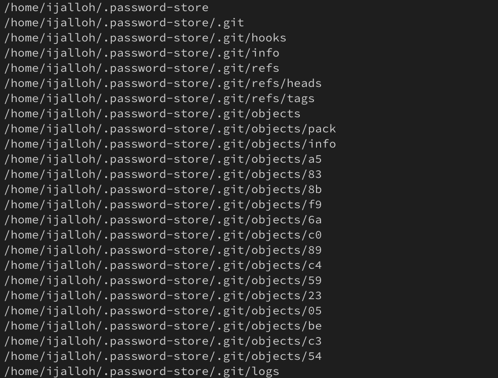

результаты find ~ -type d

# Выводы

При выполнение данной работы я ознакомился с инструментами поиска файлов и фильтрации текстовых данных. Также приобрел практические навыки по управлению процессами и по проверке использования диска по обслуживанию файловых систем.